# Calibrate conductance

Author

Justus Krantz

## Introduction

Before calibration on water balance in the study area, the the starting conductance is calculated by the water balance for the infiltration ponds themselves: By taking heads and budget changes (flows) from OM and dividing the two, giving cell conductances. This conductance dataset will be used as input for the calibration. The following diagram shows the calibration procedure:

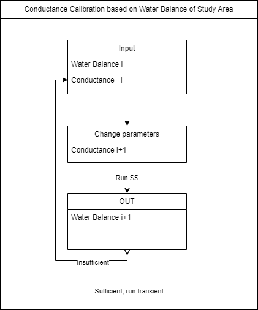

## Output - Water Balances

[figure not shown]

Calibration procedure

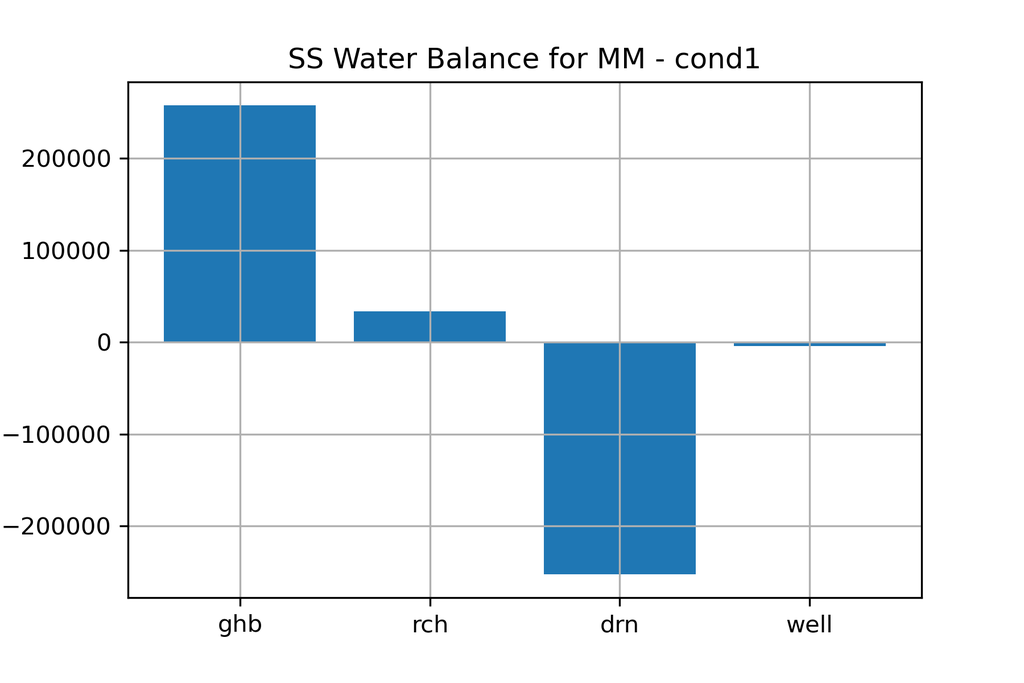

MM Water balance over study area, cond1

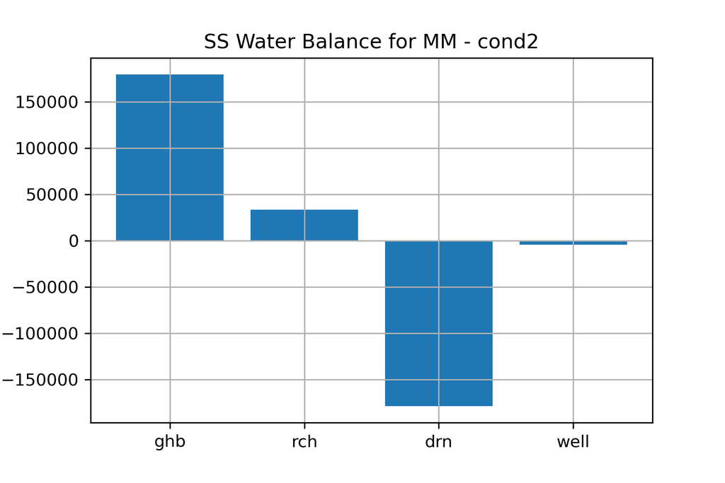

OM Water balance over study area, cond2

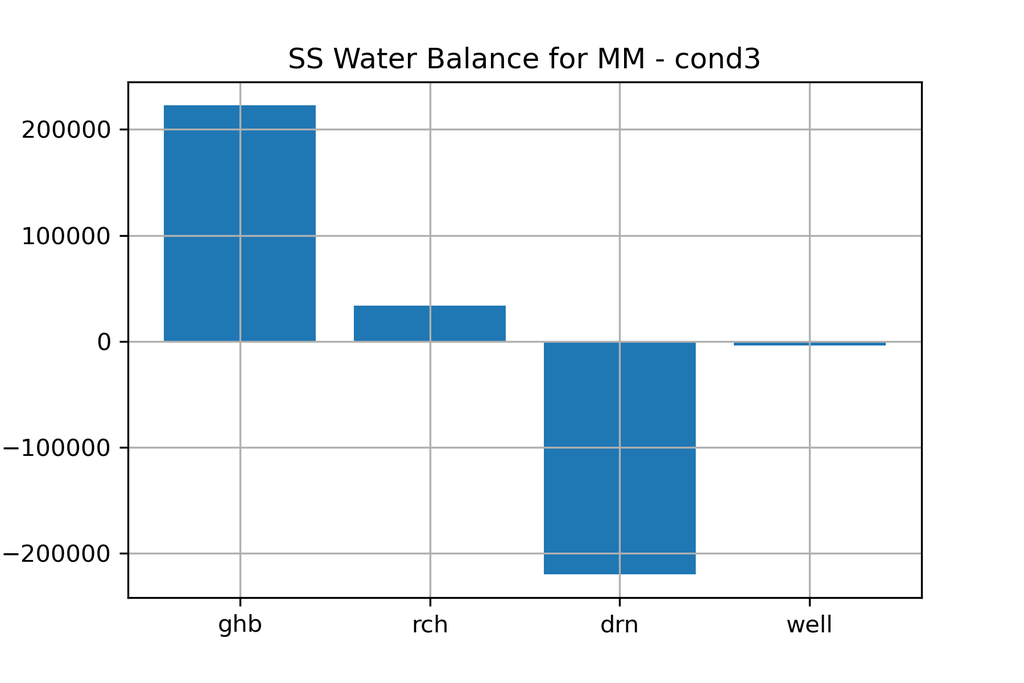

OM Water balance over study area, cond3

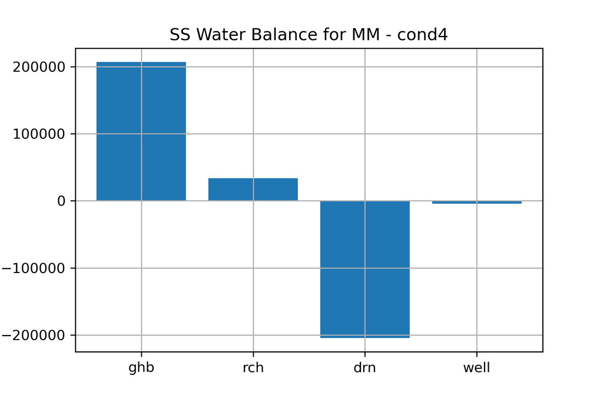

OM Water balance over study area, cond4

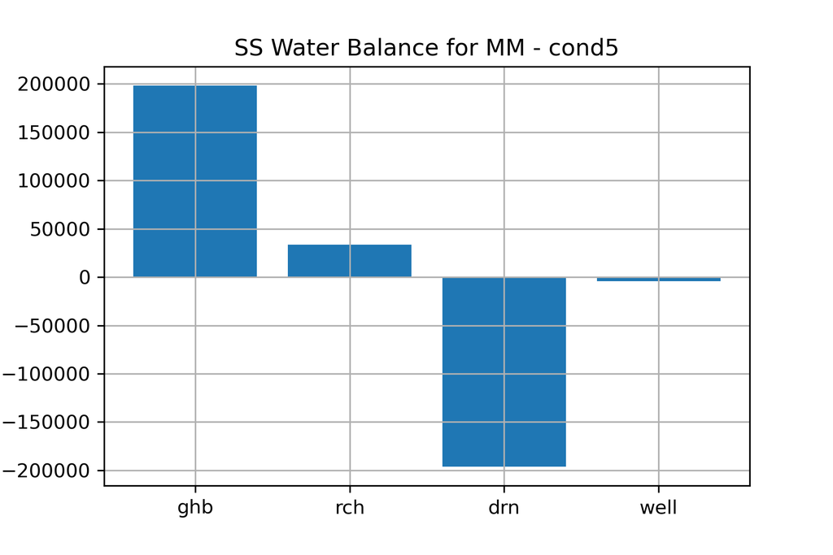

OM Water balance over study area, cond5

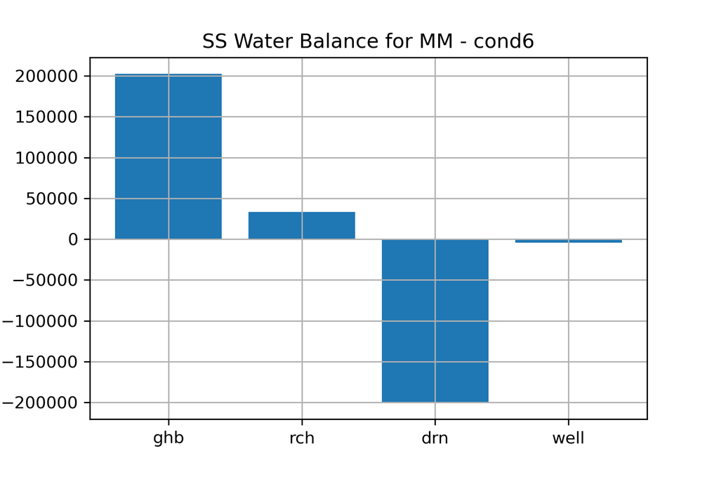

cond1 : Calculated by taking heads and budget changes (flows) from OM. dividing the two gives cell conductances.

## Output - Observations

OM:

- IP: 202230.78 m<sup>3</sup>/d
- drn: -193343 m<sup>3</sup>/d

MM(cond1)

MM(cond2)

MM(cond3)

- cond3 = 0.75 * cond1
- IP: 222650.48 m<sup>3</sup>/d
- drn: -219553.22 m<sup>3</sup>/d

MM(cond4)

- cond4 = 0.65 * cond1
- IP: 206675.44 m<sup>3</sup>/d
- drn: -204291.1 m<sup>3</sup>/d

MM(cond5)

- cond5 = 0.60 * cond1
- IP: 198116.83 m<sup>3</sup>/d
- drn: -196130.66 m<sup>3</sup>/d

## Calibrated

To calibrate on the water balance, the conductances of the infiltration ponds in the study area need to be scaled by a factor of 0.625. Now the effect on the fresh-saline interface can be investigated